# Math-Practical-Copy3- important-Major-Copy1

```
(* Settings *)
SetOptions[
    Plot3D,
    Background -> White,
    BoxStyle -> Black,
    AxesStyle -> Black,
    LabelStyle -> Black,
    TicksStyle -> Black
];

SetOptions[
    ParametricPlot,
    Background -> White,
    AxesStyle -> Black,
    LabelStyle -> Black,
    TicksStyle -> Black
];
```

Practical-1

Solution of Cauchy problem for First-Order PDE

Problem-1: To obtain the solution of the linear equation
$$ u_x - u_y = 1 $$ with the Cauchy data $ u(x, 0) = x^2 $.

Solution:

```
Clear[x, y, u, t,
    pde, initialCondition,
    solution,
    surface, initialCurve
]

pde = D[u[x, y], x] - D[u[x, y], y] == 1

initialCondition = u[x, 0] == x^2;

solution = DSolve[{pde, initialCondition}, u[x, y], {x, y}]

surface = Plot3D[
    u[x, y] /. solution, {x, -4, 4}, {y, -5, 5},
    AxesLabel -> {"x", "y", "u"},
    PlotLabel -> "Integral surface through initial curve",
    ColorFunction -> (ColorData["BlueGreenYellow"][1 - #3] &),
    ColorFunctionScaling -> True
];

initialCurve = ParametricPlot3D[
    {t, 0, t^2}, {t, -4, 4},
    PlotStyle -> {Thick, Red}
];

Show[surface, initialCurve]
```

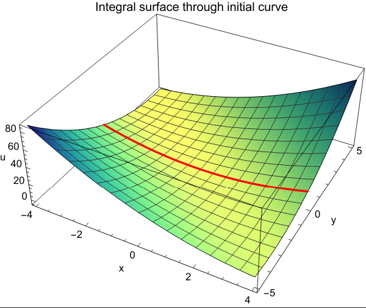

Result: The solution of the Cauchy problem for the given PDE is obtained in the output and visualized as an integral surface.

Problem-2: To obtain the solution of the linear equation
$$ u(x + y)\,u_x + u(x - y)\,u_y = x^2 + y^2 $$ with the Cauchy data $ u(x, 2x) = 0 $.

Solution:

```
Clear[x, y, u, t,
    pde, initialCondition,
    solution,
    surface, initialCurve
]

pde = u[x, y]*(x + y)*D[u[x, y], x] + u[x, y]*(x - y)*D[u[x, y], y] == x^2 + y^2

initialCondition = u[x, 2 x] == 0;

solution = DSolve[{pde, initialCondition}, u[x, y], {x, y}]

surface = Plot3D[
    u[x, y] /. solution, {x, -4, 4}, {y, -5, 5},
    AxesLabel -> {"x", "y", "u"},
    PlotLabel -> "Integral surface through initial curve",
    ColorFunction -> (ColorData["DeepSeaColors"]),
    ColorFunctionScaling -> True
];

initialCurve = ParametricPlot3D[
    {t, 2*t, 0}, {t, -4, 4},
    PlotStyle -> {Thick, Red}
];

Show[surface, initialCurve]
```

[figure not shown]

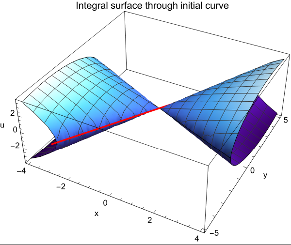

Result: The solution of the Cauchy problem for the given PDE is obtained in the output and visualized as an integral surface.

Problem-3: To obtain the solution of the linear equation
$$ u_x + u_y = u^2 $$ (a) with the Cauchy data $ x + y = 0 $, $ u = 1 $.
(b) with the Cauchy data $ u(x, 0) = \tanh{(x)} $.

Solution:

(a)

```
Clear[x, y, u, t,
    pde, initialCondition,
    solution,
    surface, initialCurve
]

pde = D[u[x, y], x] + D[u[x, y], y] == (u[x, y])^2

(* x + y = 0, u = 1 => y = -x, u = 1 => u[x, -x] = 1 *)
initialCondition = u[x, -x] == 1;

solution = DSolve[{pde, initialCondition}, u[x, y], {x, y}]

surface = Plot3D[
    u[x, y] /. solution, {x, -10, 10}, {y, -10, 10},
    AxesLabel -> {"x", "y", "u"},
    PlotLabel -> "Integral surface through initial curve",
    PlotStyle -> Cyan
];

initialCurve = ParametricPlot3D[
    {t, -t, 1}, {t, -10, 10},
    PlotStyle -> {Thick, Red}
];

Show[surface, initialCurve]
```

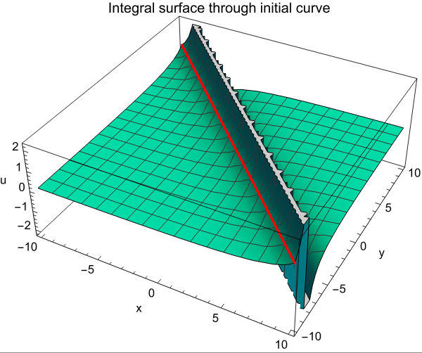

(b)

```
Clear[x, y, u, t,
    pde, initialCondition,
    solution,
    surface, initialCurve
]

pde = D[u[x, y], x] + D[u[x, y], y] == (u[x, y])^2

initialCondition = u[x, 0] == Tanh[x];

solution = DSolve[{pde, initialCondition}, u[x, y], {x, y}]

surface = Plot3D[
    u[x, y] /. solution, {x, -10, 10}, {y, -10, 10},
    AxesLabel -> {"x", "y", "u"},
    PlotLabel -> "Integral surface through initial curve",
    ColorFunction -> (ColorData["DeepSeaColors"]),
    ColorFunctionScaling -> True
];

initialCurve = ParametricPlot3D[
    {t, 0, Tanh[t]}, {t, -10, 10},
    PlotStyle -> {Thick, Red}
];

Show[surface, initialCurve]
```

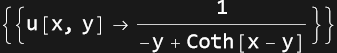

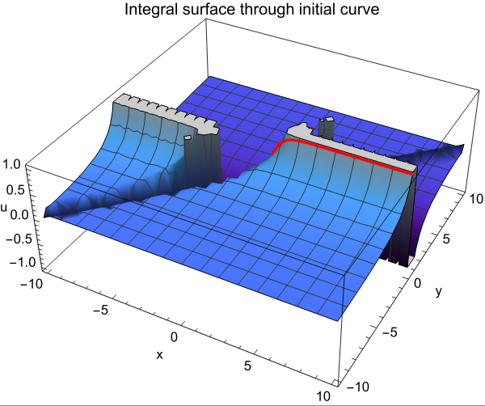

Result: The solution of the Cauchy problem for the given PDE is obtained in the output and visualized as an integral surface.

Practical-2

Plotting the Characteristics for the First-Order PDE

Problem-1: To find the characteristics of the equation
$$ \left (u - y \right )\,u_x + y \,u_y = x + y $$ and plot them.

Solution:

The auxiliary equations of the given PDE is
$$ \dfrac{dx}{u - y} = \dfrac{dy}{y} = \dfrac{du}{x + y} \tag{1} $$ We have,
$$ \Rightarrow \dfrac{dx + du}{(u - y) + (x + y)} = \dfrac{dy}{y} $$ $$ \Rightarrow \dfrac{d(x + u)}{x + u} = \dfrac{dy}{y} $$ $$ \Rightarrow \int \dfrac{d(x + u)}{x + u} = \int \dfrac{dy}{y} $$ $$ \Rightarrow \log{(x + u)} = \log{(y)} + \log{(c_1)} $$ $$ \Rightarrow \dfrac{x + u}{y} = c_1 $$ $$ \therefore\; u = y\,c_1 - x \tag{2} $$ Here, $ c_1 $ is a constant.
Again, we have from Eq.(1), $$ \Rightarrow \dfrac{dx + dy}{(u - y) + y} = \dfrac{du}{x+y} $$ $$ \Rightarrow \dfrac{d(x + y)}{u} = \dfrac{du}{x+y} $$ $$ \Rightarrow (x+y)\,d(x+y) = u\,du $$ $$ \Rightarrow \int (x+y)\,d(x+y) = \int u\,du $$ $$ \Rightarrow \dfrac{(x+y)^2}{2} = \dfrac{u^2}{2} + \dfrac{c_2}{2} $$ $$ \Rightarrow (x+y)^2 - u^2 = c_2 $$ $$ \therefore\; u = \sqrt{\left(x+y\right)^2 - c_2} \tag{3}$$
Here, $ c_2 $ is a constant.

```
Clear[f0, f1, f2, h0, h1, h2]

(* for c1 = 0, 5, 10 *)
f0 = Plot3D[-x, {x, -5, 5}, {y, -5, 5},
    AxesLabel -> {"x", "y", "u"},
    PlotLabel -> "Characteristics of Eq.(2) for c1 = 0, 5, 10",
    ColorFunction -> (Blend[{Cyan, Magenta}, #3] &),
    ColorFunctionScaling -> True
];
f1 = Plot3D[5*y - x, {x, -5, 5}, {y, -5, 5},
    ColorFunction -> (Blend[{Cyan, Magenta}, #3] &),
    ColorFunctionScaling -> True
];
f2 = Plot3D[10*y - x, {x, -5, 5}, {y, -5, 5},
    ColorFunction -> (Blend[{Cyan, Magenta}, #3] &),
    ColorFunctionScaling -> True
];

Show[f0, f1, f2]

(* for c2= 0, 5, 10 *)
h0 = Plot3D[x + y, {x, -5, 5}, {y, -5, 5},
    AxesLabel -> {"x", "y", "u"},
    PlotLabel -> "Characteristics of Eq.(3) for c2 = 0, 5, 10",
    ColorFunction -> (ColorData["DeepSeaColors"][1 - #3] &),
    ColorFunctionScaling -> True
];
h1 = Plot3D[Sqrt[(x + y)^2 + 5], {x, -5, 5}, {y, -5, 5},
    ColorFunction -> (ColorData["DeepSeaColors"][1 - #3] &),
    ColorFunctionScaling -> True
];
h2 = Plot3D[Sqrt[(x + y)^2 + 10], {x, -5, 5}, {y, -5, 5},
    ColorFunction -> (ColorData["DeepSeaColors"][1 - #3] &),
    ColorFunctionScaling -> True
];

Show[h0, h1, h2]
```

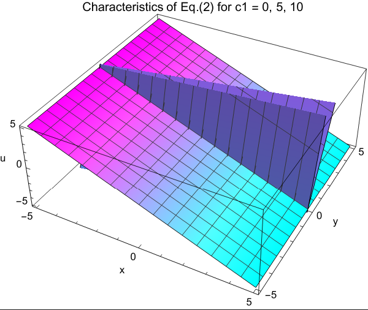

[figure not shown]

Result: The characteristics of the given PDE are plotted in the output.

Practical-3

Plotting the Integral Surfaces of a given First-Order PDE with Initial Data

Problem-1: To find the solution of the equation
$$ u_x + y\, u_y = 0 $$ with the Cauchy data $ u(0, y) = 4\,y $.
Plot the integral surface with in the range $ (x, -4, 4) $ & $ (y, -5, 5) $.

Solution:

```
Clear[x, y, u, t,
    pde, initialCondition,
    solution,
    surface, initialCurve
]

pde = D[u[x, y], x] + y*D[u[x, y], y] == 0

initialCondition = u[0, y] == 4*y;

solution = DSolve[{pde, initialCondition}, u[x, y], {x, y}]

Plot3D[
    u[x, y] /. solution, {x, -4, 4}, {y, -5, 5},
    AxesLabel -> {"x", "y", "u"},
    PlotLabel -> "Integral surface",
    ColorFunction -> (Blend[{Cyan, Magenta}, #3] &),
    ColorFunctionScaling -> True
]
```

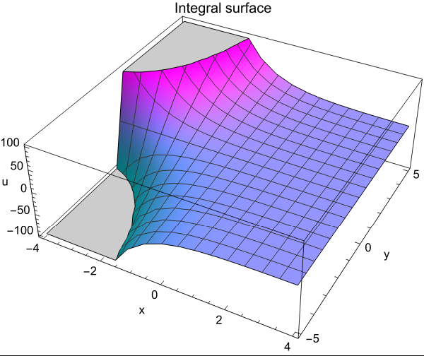

Result: The solution of the Cauchy problem for the given PDE is obtained in the output and visualized as an integral surface.

Problem-2: To obtain the solution of the equation
$$ u_x + u\, u_y = 1 $$ with the Cauchy data $ u(0, y) = 4\,y $.
Plot the integral surface with in the range $ (x, -4, 4) $ & $ (y, -5, 5) $.

Solution:

```
Clear[x, y, u, t,
    pde, initialCondition,
    solution,
    surface, initialCurve
]

pde = D[u[x, y], x] + u[x, y]*D[u[x, y], y] == 1

initialCondition = u[0, y] == 4*y;

solution = DSolve[{pde, initialCondition}, u[x, y], {x, y}]

Plot3D[
    u[x, y] /. solution, {x, -4, 4}, {y, -5, 5},
    AxesLabel -> {"x", "y", "u"},
    PlotLabel -> "Integral surface",
    ColorFunction -> "AvocadoColors",
    ColorFunctionScaling -> True
]
```

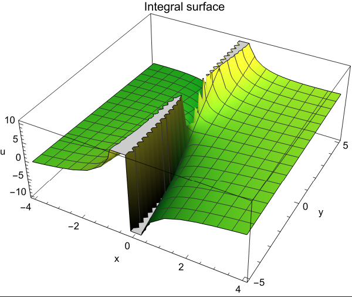

Result: The solution of the Cauchy problem for the given PDE is obtained in the output and visualized as an integral surface.

Problem-3: To obtain the solution of the equation
$$ u_x + u_y = 1 $$ with the Cauchy data $ u(x, 2x) = x^3 $.
Plot the integral surface with in the range $ (x, -4, 4) $ & $ (y, -5, 5) $.

Solution:

```
Clear[x, y, u, t,
    pde, initialCondition,
    solution,
    surface, initialCurve
]

pde = D[u[x, y], x] + D[u[x, y], y] == 1

initialCondition = u[x, 2 x] == x^3;

solution = DSolve[{pde, initialCondition}, u[x, y], {x, y}]

Plot3D[
    u[x, y] /. solution, {x, -4, 4}, {y, -5, 5},
    AxesLabel -> {"x", "y", "u"},
    PlotLabel -> "Integral surface",
    ColorFunction -> (ColorData["BlueGreenYellow"][1 - #3] &),
    ColorFunctionScaling -> True
]
```

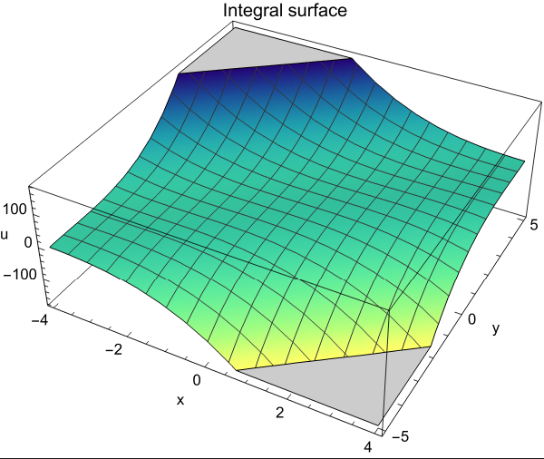

Result: The solution of the Cauchy problem for the given PDE is obtained in the output and visualized as an integral surface.